# Detecção de Fraudes no Tráfego de Cliques em Propagandas de Aplicações Mobile

Gilson Santana - gcardososantana@gmail.com

02/11/2020

## Arquivos que compõe o projeto, inclusive a presente página em PDF

Readme

Detecção de Fraude - Solução em PDF

Arquivo .Rmd

Arquivo de dados CSV

Dicionário de dados

## Informações gerais

Projeto da DSA como parte do treiamento Big Data Analytics com R e Microsoft Azure Machine Learning.

O projeto consiste na criação de modelo de Machine Learning que possa prever se um click para download de aplicativo é ou não fraudulento. Para esse trabalho foi utilizado a base de dados train_sample.csv, disponível no link https://www.kaggle.com/c/talkingdata-adtracking-fraud-detection/data. Maiores detalhe do desafio também pode ser obtido no site do Kaggle.

Acesse o arquivo Readme para informações complementares.

## Carga & visualização

```r
oldw <- getOption("warn")
options(warn = -1)

library(dplyr)
library(ROSE)
library(lubridate)
```

```r
library(ggplot2)
library(gridExtra)
#Diretório de trabalho
setwd('D:/OneDrive/EstudosTecnicos/CienciaDados/DtScienceTrab/BigDataRAzure/Cap20/Projeto01')

# Carregar dados - Utilizada a base train-sample.csv devido ao tamanho da base train
dfDados<- read.csv('train_sample.csv', stringsAsFactors= F, header =T)
```

```r
str(dfDados)
```

```
## 'data.frame':    100000 obs. of  8 variables:
##  $ ip             : int  87540 105560 101424 94584 68413 93663 17059 121505 192967 143636 ...
##  $ app            : int  12 25 12 13 12 3 1 9 2 3 ...
##  $ device         : int  1 1 1 1 1 1 1 1 2 1 ...
##  $ os             : int  13 17 19 13 1 17 17 25 22 19 ...
##  $ channel        : int  497 259 212 477 178 115 135 442 364 135 ...
##  $ click_time     : chr  "2017-11-07 09:30:38" "2017-11-07 13:40:27" "2017-11-07 18:05:24" "2017-11-07 04:58:08" ...
##  $ attributed_time: chr  "" "" "" "" ...
##  $ is_attributed  : int  0 0 0 0 0 0 0 0 0 0 ...
```

```r
# View(dfDados)
summary(dfDados)
```

```
##        ip              app             device              os
##  Min.   :     9   Min.   :  1.00   Min.   :   0.00   Min.   :  0.00
##  1st Qu.: 40552   1st Qu.:  3.00   1st Qu.:   1.00   1st Qu.: 13.00
##  Median : 79827   Median : 12.00   Median :   1.00   Median : 18.00
##  Mean   : 91256   Mean   : 12.05   Mean   :  21.77   Mean   : 22.82
##  3rd Qu.:118252   3rd Qu.: 15.00   3rd Qu.:   1.00   3rd Qu.: 19.00
##  Max.   :364757   Max.   :551.00   Max.   :3867.00   Max.   :866.00
##     channel       click_time        attributed_time    is_attributed
##  Min.   :  3.0   Length:100000      Length:100000      Min.   :0.00000
##  1st Qu.:145.0   Class :character   Class :character   1st Qu.:0.00000
##  Median :258.0   Mode  :character   Mode  :character   Median :0.00000
##  Mean   :268.8                                         Mean   :0.00227
##  3rd Qu.:379.0                                         3rd Qu.:0.00000
##  Max.   :498.0                                         Max.   :1.00000
```

## Explorar

Download (e o não download) do App por número de clicks repetidos para diversas variáveis

A quantidade de cliks que não resultam em download para o mesmo IP chama a atenção, sugere fraude. Em outras variáveis essa característica é semelhante, porém não sugestiona fraude na mesma proporção do IP.

```r
     # ip
     #par(mfrow = c(1,2))
     dfAux<- dfDados %>%
          select(is_attributed, ip) %>%
          group_by(is_attributed, ip) %>%
          summarise(repeticoes=n())
```

```r
     plot01<- dfAux %>% filter(is_attributed == 1) %>% arrange(desc(repeticoes)) %>% head(6)  %>%
          ggplot(aes(factor(ip), repeticoes)) +
          geom_col() +
          ggtitle('Qtde clicks-IP-APPs baixados-TOP 6') +
          xlab('IPs') +
          ylab('Qtde de clicks por IP')

     plot02<- dfAux %>% filter(is_attributed == 0) %>% arrange(desc(repeticoes)) %>% head(6) %>%
          ggplot(aes(factor(ip), repeticoes)) +
          geom_col() +
          ggtitle('Qtde clicks-IP-APPs NÃO baixados-TOP 6') +
          xlab('IPs') +
          ylab('Qtde de clicks por IP')

     # app
     dfAux<- dfDados %>%
          select(is_attributed, app) %>%
          group_by(is_attributed, app) %>%
          summarise(repeticoes=n())
     plot03<- dfAux %>% filter(is_attributed == 1) %>% arrange(desc(repeticoes)) %>% head(6)  %>%
          ggplot(aes(factor(app), repeticoes)) +
          geom_col() +
          ggtitle('Qtde clicks-Aplicativo-APPs baixados-TOP 6') +
          xlab('Aplicativos') +
          ylab('Qtde de clicks por Aplicativos')

     plot04<- dfAux %>% filter(is_attributed == 0) %>% arrange(desc(repeticoes)) %>% head(6) %>%
          ggplot(aes(factor(app), repeticoes)) +
          geom_col() +
          ggtitle('Qtde clicks-Aplicativo-APPs NÃO baixados-TOP 6') +
          xlab('Aplicativos') +
          ylab('Qtde de clicks por Aplicativos')


     # device
     dfAux<- dfDados %>%
          select(is_attributed, device) %>%
          group_by(is_attributed, device) %>%
          summarise(repeticoes=n())
     plot05<- dfAux %>% filter(is_attributed == 1) %>% arrange(desc(repeticoes)) %>% head(6)  %>%
          ggplot(aes(factor(device), repeticoes)) +
          geom_col() +
          ggtitle('Qtde clicks-Device-APPs baixados-TOP 6') +
          xlab('Device') +
          ylab('Qtde de clicks por Device')

     plot06<- dfAux %>% filter(is_attributed == 0) %>% arrange(desc(repeticoes)) %>% head(6) %>%
          ggplot(aes(factor(device), repeticoes)) +
          geom_col() +
          ggtitle('Qtde de clicks-Device-APPs NÃO baixados-TOP 6') +
          xlab('Device') +
          ylab('Qtde de clicks por Device')

     # OS (Sistema Operacional)
     dfAux<- dfDados %>%
          select(is_attributed, os) %>%
          group_by(is_attributed, os) %>%
          summarise(repeticoes=n())
     plot07<- dfAux %>% filter(is_attributed == 1) %>% arrange(desc(repeticoes)) %>% head(6)  %>%
          ggplot(aes(factor(os), repeticoes)) +
          geom_col() +
          ggtitle('Qtde clicks-OS-APPs baixados-TOP 6') +
          xlab('Device') +
          ylab('Qtde de clicks por OS')

     plot08<- dfAux %>% filter(is_attributed == 0) %>% arrange(desc(repeticoes)) %>% head(6) %>%
          ggplot(aes(factor(os), repeticoes)) +
          geom_col() +
          ggtitle('Qtde clicks-OS-APPs NÃO baixados-TOP 6') +
          xlab('OS') +
          ylab('Qtde de clicks por OS')

     # channel
     dfAux<- dfDados %>%
          select(is_attributed, channel) %>%
          group_by(is_attributed, channel) %>%
          summarise(repeticoes=n())
     plot09<- dfAux %>% filter(is_attributed == 1) %>% arrange(desc(repeticoes)) %>% head(6)  %>%
          ggplot(aes(factor(channel), repeticoes)) +
          geom_col() +
          ggtitle('Qtde clicks-Channel-APPs baixados-TOP 6') +
          xlab('Channel') +
          ylab('Qtde de clicks por Channel')

     plot10<- dfAux %>% filter(is_attributed == 0) %>% arrange(desc(repeticoes)) %>% head(6) %>%
          ggplot(aes(factor(channel), repeticoes)) +
          geom_col() +
          ggtitle('Qtde clicks-Channel-APPs NÃO baixados-TOP 6') +
          xlab('Channel') +
          ylab('Qtde de clicks por Channel')
```

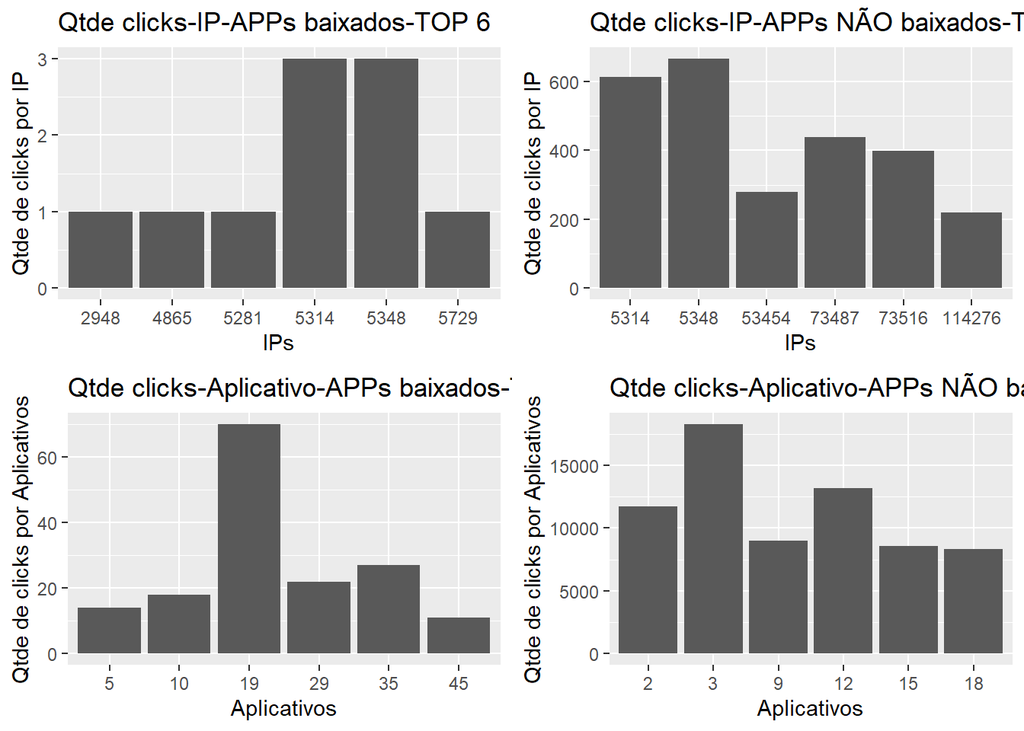

```r
          #Exibir plots
     grid.arrange(plot01, plot02, plot03, plot04, ncol=2, nrow=2)
```

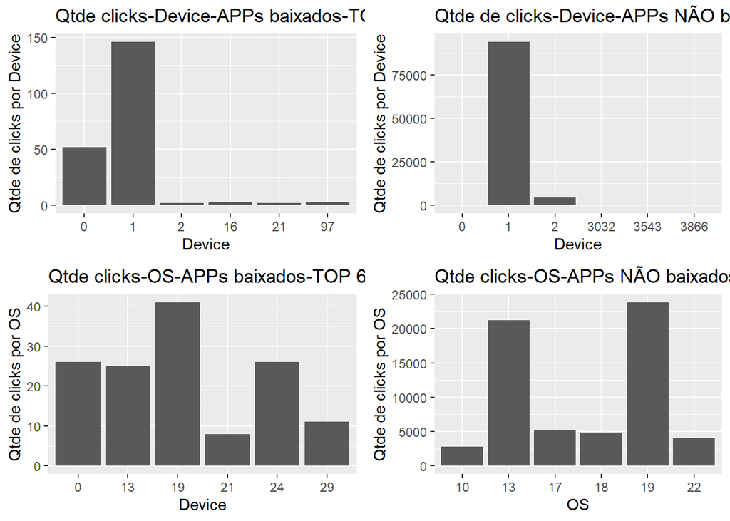

```r
     grid.arrange(plot05, plot06, plot07, plot08, ncol=2, nrow=2)
```

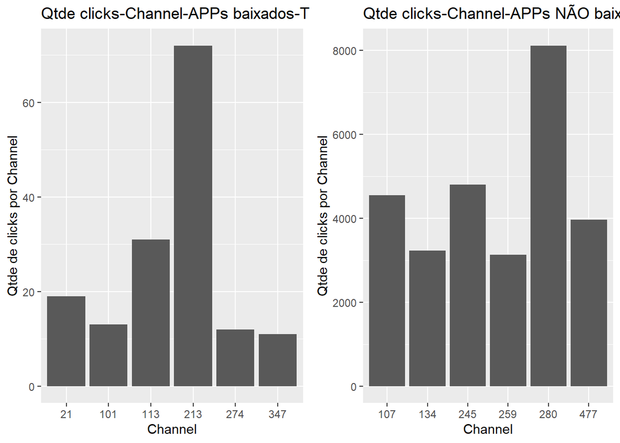

```r
     grid.arrange(plot09, plot10, ncol=2, nrow=1)
```

## Relação attributed_time X is_attributed

Se App baixado implica na existendia do atributed_time, assim essa variável é consequência da variável target (is_attributed), não pode figurar como perditora

```r
     nrow(dfDados %>% filter(attributed_time == ''))
```

```
## [1] 99773
```

```r
     nrow(dfDados %>% filter(is_attributed == '0'))
```

```
## [1] 99773
```

```r
     nrow(dfDados %>% filter(attributed_time == '' & is_attributed == '0'))
```

```
## [1] 99773
```

```r
     dfDados$attributed_time <- NULL
```

## Análise temporal

Variável click_time - indica o momento do click.

```r
     dfDados$dt <- date(dfDados$click_time)
     dfDados$year <- year(dfDados$dt)
     dfDados$month <- month(dfDados$dt)
     dfDados$day <- day(dfDados$dt)
     dfDados$weekday <- wday(dfDados$dt)
     dfDados$hour <- hour(dfDados$click_time)
     str(dfDados)
```

```
## 'data.frame':    100000 obs. of  13 variables:
##  $ ip           : int  87540 105560 101424 94584 68413 93663 17059 121505 192967 143636 ...
##  $ app          : int  12 25 12 13 12 3 1 9 2 3 ...
##  $ device       : int  1 1 1 1 1 1 1 1 2 1 ...
##  $ os           : int  13 17 19 13 1 17 17 25 22 19 ...
##  $ channel      : int  497 259 212 477 178 115 135 442 364 135 ...
##  $ click_time   : chr  "2017-11-07 09:30:38" "2017-11-07 13:40:27" "2017-11-07 18:05:24" "2017-11-07 04:58:08" ...
##  $ is_attributed: int  0 0 0 0 0 0 0 0 0 0 ...
##  $ dt           : Date, format: "2017-11-07" "2017-11-07" ...
##  $ year         : num  2017 2017 2017 2017 2017 ...
##  $ month        : num  11 11 11 11 11 11 11 11 11 11 ...
##  $ day          : int  7 7 7 7 9 9 9 7 8 8 ...
##  $ weekday      : num  3 3 3 3 5 5 5 3 4 4 ...
##  $ hour         : int  9 13 18 4 9 1 1 10 9 12 ...
```

```r
     # year e month - essas variáveis tem uma dimensão apenas, é
     # como uma constante. A amostra se resuma a um ano e um mês, apenas
     str(factor(dfDados$year))
```

```
##  Factor w/ 1 level "2017": 1 1 1 1 1 1 1 1 1 1 ...
```

```r
     str(factor(dfDados$month))
```

```
##  Factor w/ 1 level "11": 1 1 1 1 1 1 1 1 1 1 ...
```

```r
     dfDados$year <- NULL
     dfDados$month <- NULL

     # day e weekday - se tornaram redudantes devido ao tamanho da amostra: apenas
     # 4 dias consecutivos no mês 11 de 2017, sendo que não contempla fim de semana
     # nem sinaliza feriados. Qualquer análise de comportamento na linha semanal ou
     # de períodos mensais seria "forçação" de barra.
     # Foi mantida a variável day e eliminada a weekday
     str(factor(dfDados$day))
```

```
##  Factor w/ 4 levels "6","7","8","9": 2 2 2 2 4 4 4 2 3 3 ...
```

```r
     dfDados %>% distinct(day) %>% arrange(day)
```

```
##   day
## 1   6
## 2   7
## 3   8
## 4   9
```

```r
     str(factor(dfDados$weekday))
```

```
##  Factor w/ 4 levels "2","3","4","5": 2 2 2 2 4 4 4 2 3 3 ...
```

```r
     dfDados %>% distinct(weekday) %>% arrange(weekday)
```

```
##   weekday
## 1       2
## 2       3
## 3       4
## 4       5
```

```r
     dfDados$weekday <- NULL


     # hour - Avaliar comportamento por hora
     # O desbalanceamento da classe is_attributed é muito acentuado, isso limita os insighs
     # Recomenda-se repetir a análise após o balanceamento da classe. Poderá ser feito em uma
     # continuidade desse trabalho.
     # Para um análise temporal, a amostra se apresentou bastante limitada.
     dfAux<- dfDados %>%
          select(is_attributed, day, hour) %>%
          group_by(is_attributed, day, hour) %>%
          summarise(qtdCliks=n())
```

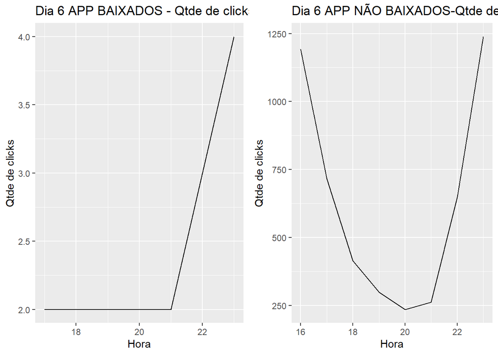

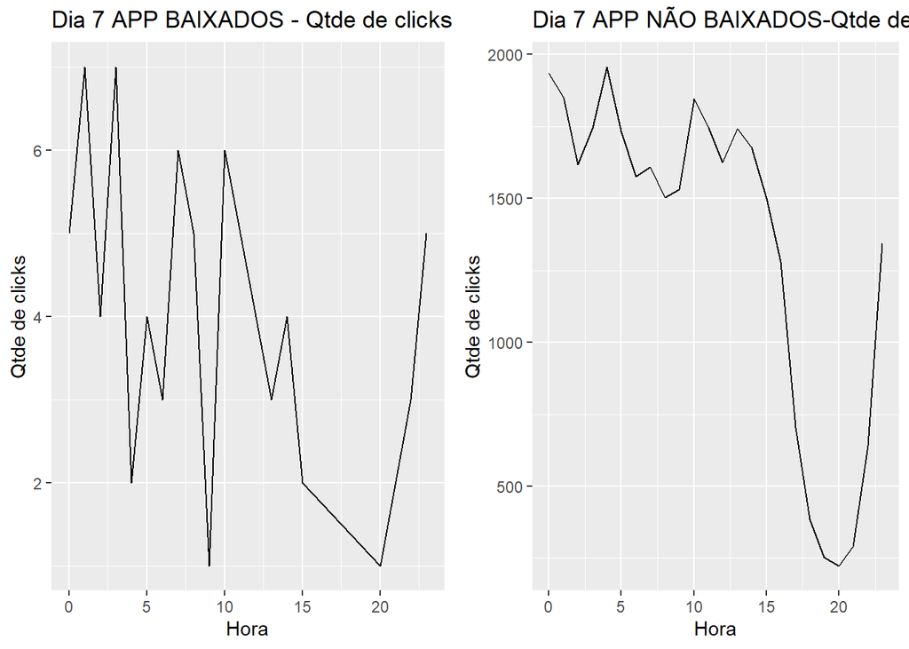

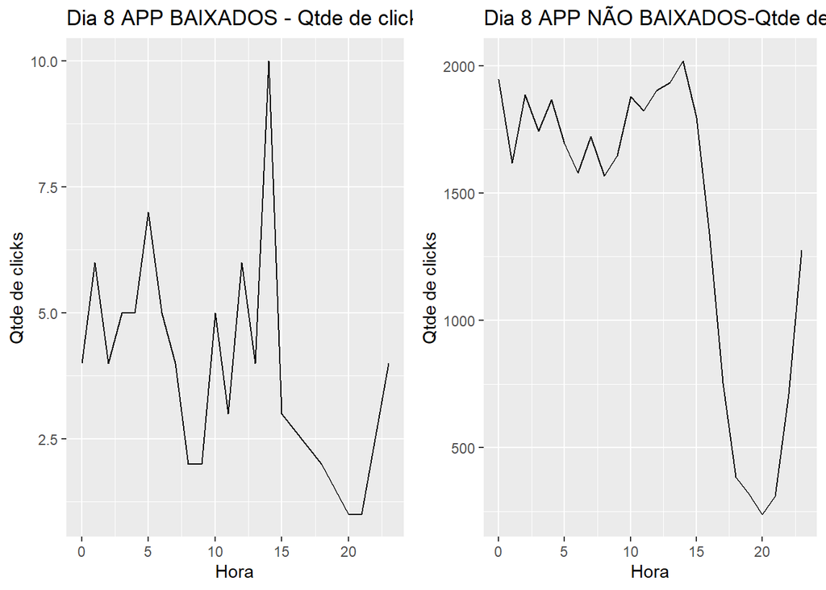

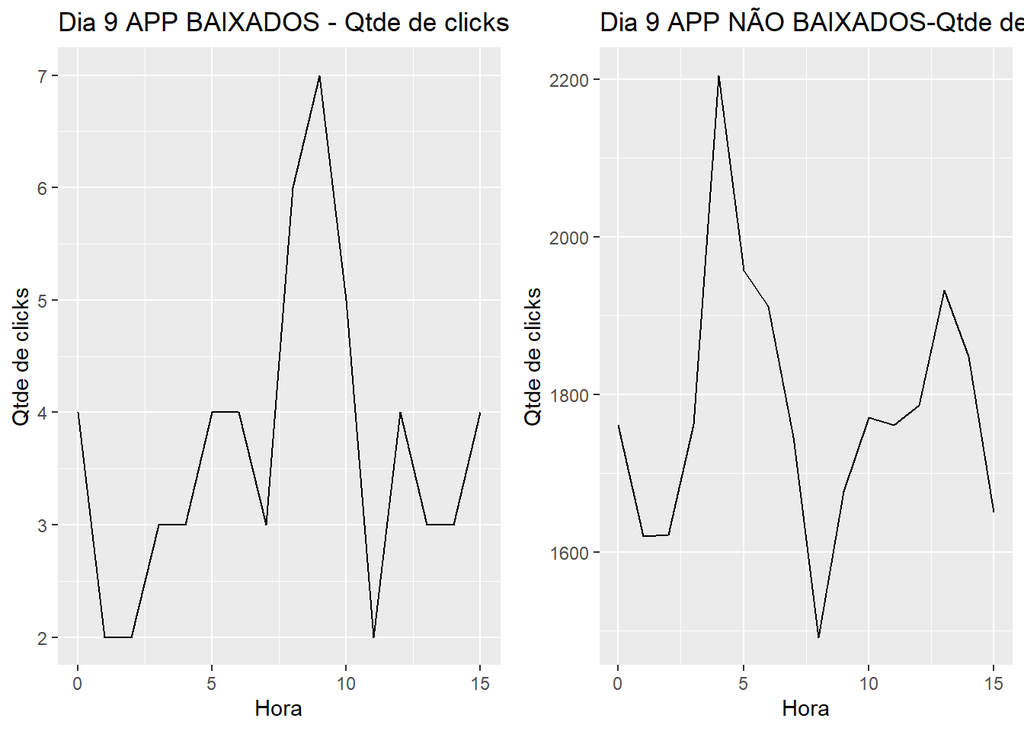

```
## $day1
## TableGrob (1 x 2) "arrange": 2 grobs
##   z     cells    name           grob
## 1 1 (1-1,1-1) arrange gtable[layout]
## 2 2 (1-1,2-2) arrange gtable[layout]
##
## $day2
## TableGrob (1 x 2) "arrange": 2 grobs
##   z     cells    name           grob
## 1 1 (1-1,1-1) arrange gtable[layout]
## 2 2 (1-1,2-2) arrange gtable[layout]
##
## $day3
## TableGrob (1 x 2) "arrange": 2 grobs
##   z     cells    name           grob
## 1 1 (1-1,1-1) arrange gtable[layout]
## 2 2 (1-1,2-2) arrange gtable[layout]
##
## $day4
## TableGrob (1 x 2) "arrange": 2 grobs
##   z     cells    name           grob
## 1 1 (1-1,1-1) arrange gtable[layout]
## 2 2 (1-1,2-2) arrange gtable[layout]
```

```r
     # Função - plotagem por dia
     plotD <- function(dia){
          plotd1<- ggplot(dfAux[dfAux$is_attributed == 1 & dfAux$day == dia,], aes(x = hour, y = qtdCliks)) +
               geom_line() +
               ylab("Qtde de clicks") + xlab("Hora") +
               labs(title = paste("Dia ", as.character(dia), " APP BAIXADOS - Qtde de clicks por hora", sep = ""))

          plotd2<- ggplot(dfAux[dfAux$is_attributed == 0 & dfAux$day == dia,], aes(x = hour, y = qtdCliks)) +
               geom_line() +
               ylab("Qtde de clicks") + xlab("Hora") +
               labs(title = paste("Dia ", as.character(dia), " APP NÃO BAIXADOS-Qtde de clicks por hora", sep = ""))

          grid.arrange(plotd1 , plotd2, ncol=2, nrow=1)
     }

     dias<- unlist(distinct(dfAux[, 'day']))
     lapply(dias, plotD)
```

## Análise de correlação

[figure not shown]

```r
     library(corrgram)
     corrgram(dfDados)
```

## Variáveis categóricas

Reconhecer as variáveis categóricas do dataset. Foram disponisibilizadas com o tipo inteiro

```r
     toFactor<- function(df, var) {
          for(v in var) df[,v]= factor(df[,v])
          return(df)
     }

     VarToFactor<- c('ip', 'app','device','os','channel','is_attributed', 'day', 'hour')
     dfDados<- toFactor(dfDados, VarToFactor)
```

## Valores missing

Checar e tratar valores missing

```r
# Tratar valores NA - Não tem valores missing
     any(is.na(dfDados))
```

```
## [1] FALSE
```

## Dados de teste e treino

```r
#Divisão dos dados de teste e treino
     linhas <- sample(1:nrow(dfDados), 0.7 * nrow(dfDados))
     dfTrain <- dfDados[linhas,]
     dfTest <- dfDados[-linhas,]
```

## Balanceamento de classe

O dataset está bastante desbalenceado em relação a classe is_attributed, variável target.

```r
#Balanceamento - Oversampling - is_attributed - muito mais registros com valor 0
     summary(dfTrain$is_attributed)
```

```
##     0     1
## 69851   149
```

```r
     prop.table(table(dfTrain$is_attributed))
```

```
##
##           0           1
## 0.997871429 0.002128571
```

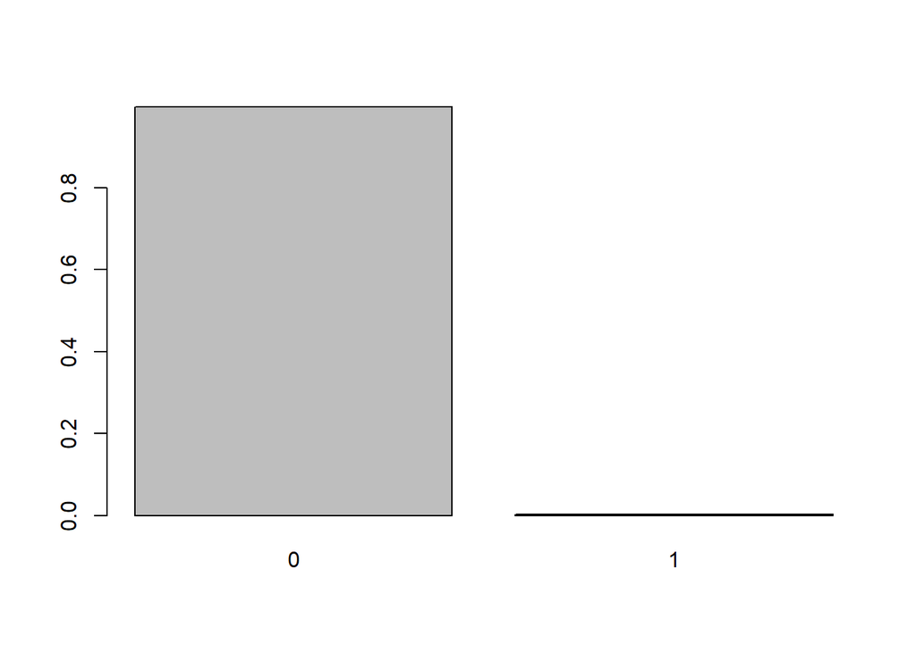

```r
     barplot(prop.table(table(dfTrain$is_attributed)))
```

```r
     dfTrainBal <- ROSE(is_attributed ~ ip +
                          app +
                          device +
                          os +
                          channel +
                          day +
                          hour,
                     data = dfTrain, seed = 1)$data

     # Nova Proporção
     summary(dfTrainBal$is_attributed)
```

```
##     0     1
## 34919 35081
```

```r
     prop.table(table(dfTrainBal$is_attributed))
```

```
##
##         0         1
## 0.4988429 0.5011571
```

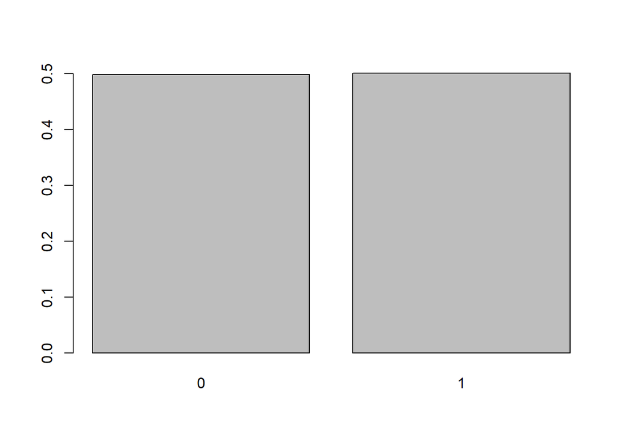

```r
     barplot(prop.table(table(dfTrainBal$is_attributed)))
```

```r
     any(is.na(dfTrainBal))
```

```
## [1] FALSE
```

```r
# Balancear Teste
     dfTestBal <- ROSE(is_attributed ~ ip +
                            app +
                            device +
                            os +
                            channel +
                            day +
                            hour,
                       data = dfTest, seed = 1)$data
     summary(dfTestBal$is_attributed)
```

```
##     0     1
## 15121 14879
```

```r
     prop.table(table(dfTestBal$is_attributed))
```

```
##
##         0         1
## 0.5040333 0.4959667
```

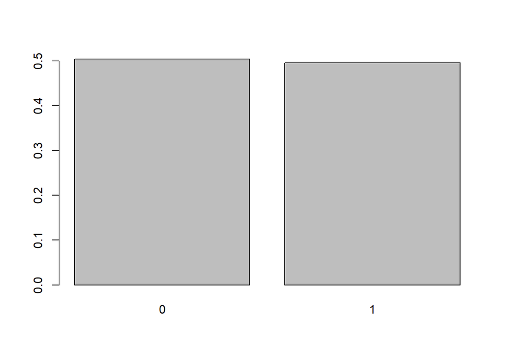

```r
     barplot(prop.table(table(dfTestBal$is_attributed)))
```

```r
     any(is.na(dfTestBal))
```

```
## [1] FALSE
```

## Treinando modelos

OBS: O Radom Forest não aceita trabalhar com variáveis categóricas com mais de 53 níveis. Por esse motivo, algumas Variáveis foram ajustadas para o tipo character.

```r
     library(C50) #algorítimo C5.0
     library(e1071) #naiveBayes
     library(randomForest)
     #Árvore de decisão - algorítimo C5.0
     m.Arvore1 <- C5.0(is_attributed ~ ., data = dfTrainBal, rules = TRUE)

     # naiveBayes
     m.Naive1<- naiveBayes(is_attributed ~ ., data = dfTrainBal, laplace = 0)

     # Radom Forest - Não aceita trabalhar com factor com mais de 53 níveis. Variáveis
     # ajustadas para o tipo character.
     dfTrainBalRandom<- dfTrainBal
     dfTrainBalRandom$ip<- as.character(dfTrainBalRandom$ip)
     dfTrainBalRandom$app<- as.character(dfTrainBalRandom$app)
     dfTrainBalRandom$device<- as.character(dfTrainBalRandom$device)
     dfTrainBalRandom$os<- as.character(dfTrainBalRandom$os)
     dfTrainBalRandom$channel<- as.character(dfTrainBalRandom$channel)
     #str(dfTrainBalRandom)

     m.Random1 <- randomForest( is_attributed ~ ip +
                                  app +
                                  device +
                                  os +
                                  channel +
                                  day +
                                  hour,
                             data = dfTrainBalRandom,
                             ntree = 100, nodesize = 10)
```

## Predição e avaliação

```r
# Predições
     p.Arvore1<- predict(m.Arvore1, dfTestBal)
     p.Naive1<- predict(m.Naive1, dfTestBal)

     dfTestBalRandom<- dfTestBal
     dfTestBalRandom$ip<- as.character(dfTestBalRandom$ip)
     dfTestBalRandom$app<- as.character(dfTestBalRandom$app)
     dfTestBalRandom$device<- as.character(dfTestBalRandom$device)
     dfTestBalRandom$os<- as.character(dfTestBalRandom$os)
     dfTestBalRandom$channel<- as.character(dfTestBalRandom$channel)
     p.Random1<- predict(m.Random1, dfTestBalRandom)
```

```r
#Avaliando predições
     library(caret)
     confusionMatrix(dfTestBal$is_attributed, p.Arvore1)
```

```
## Confusion Matrix and Statistics
##
##           Reference
## Prediction     0     1
##          0 13947  1174
##          1  4206 10673
##
##                Accuracy : 0.8207
##                  95% CI : (0.8163, 0.825)
##     No Information Rate : 0.6051
##     P-Value [Acc > NIR] : < 2.2e-16
##
##                   Kappa : 0.6407
##
##  Mcnemar's Test P-Value : < 2.2e-16
##
##             Sensitivity : 0.7683
##             Specificity : 0.9009
##          Pos Pred Value : 0.9224
##          Neg Pred Value : 0.7173
##              Prevalence : 0.6051
##          Detection Rate : 0.4649
##    Detection Prevalence : 0.5040
##       Balanced Accuracy : 0.8346
##
##        'Positive' Class : 0
##
```

```r
     confusionMatrix(dfTestBal$is_attributed, p.Naive1)
```

```
## Confusion Matrix and Statistics
##
##           Reference
## Prediction     0     1
##          0 13993  1128
##          1   964 13915
##
##                Accuracy : 0.9303
##                  95% CI : (0.9273, 0.9331)
##     No Information Rate : 0.5014
##     P-Value [Acc > NIR] : < 2.2e-16
##
##                   Kappa : 0.8605
##
##  Mcnemar's Test P-Value : 0.0003656
##
##             Sensitivity : 0.9355
##             Specificity : 0.9250
##          Pos Pred Value : 0.9254
##          Neg Pred Value : 0.9352
##              Prevalence : 0.4986
##          Detection Rate : 0.4664
##    Detection Prevalence : 0.5040
##       Balanced Accuracy : 0.9303
##
##        'Positive' Class : 0
##
```

```r
     confusionMatrix(dfTestBal$is_attributed, p.Random1)
```

```
## Confusion Matrix and Statistics
##
##           Reference
## Prediction     0     1
##          0 15115     6
##          1 14670   209
##
##                Accuracy : 0.5108
##                  95% CI : (0.5051, 0.5165)
##     No Information Rate : 0.9928
##     P-Value [Acc > NIR] : 1
##
##                   Kappa : 0.0138
##
##  Mcnemar's Test P-Value : <2e-16
##
##             Sensitivity : 0.50747
##             Specificity : 0.97209
##          Pos Pred Value : 0.99960
##          Neg Pred Value : 0.01405
##              Prevalence : 0.99283
##          Detection Rate : 0.50383
##    Detection Prevalence : 0.50403
##       Balanced Accuracy : 0.73978
##
##        'Positive' Class : 0
##
```

```r
# ROC Curves com o ROSE
     roc.curve(dfTestBal$is_attributed, p.Arvore1, plotit = T, col = "orange", add.roc = F)
```

```
## Area under the curve (AUC): 0.820
```

```r
     roc.curve(dfTestBal$is_attributed, p.Naive1, plotit = T, col = "red", add.roc = T)
```

```
## Area under the curve (AUC): 0.930
```

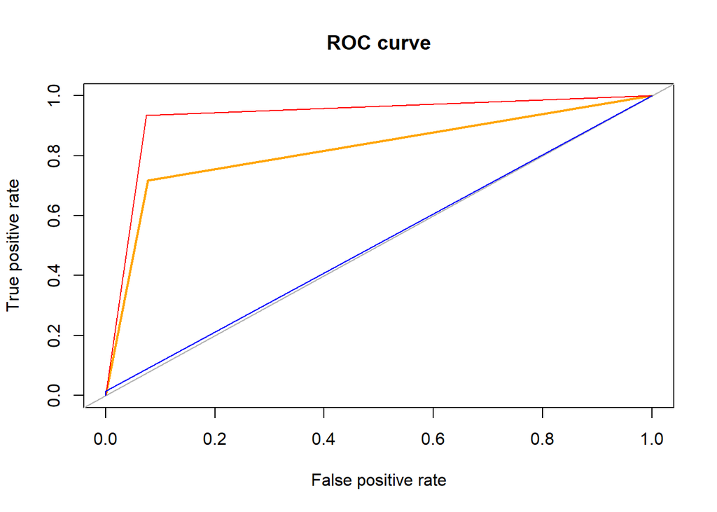

```
## Area under the curve (AUC): 0.507
```

```r
     roc.curve(dfTestBal$is_attributed, p.Random1, plotit = T, col = "blue", add.roc = T)
```

```r
options(warn = oldw)
```

## Conclusões

O moldelo baseado no Naive apresentou melhor acurácia, poderia seguir com um refinamento do processo de otimização.

O C5.0 vem em seguida. Apresenta também como candidado a seguir com uma otimização.

O modelo de Radom Forest não conseguiu rodar com as variáveis categóricas (factor) com mais de 53 níveis. Assim, algumas variáveis foram convertidas para caracter. isso pode ter influenciando no seu baixo desempenho.

OBS: aqui não se fez um trabalho expoloratório com os dados balanceados por se tratar de um projeto acadêmico, cuja finalidade maior é foi o exercício inicial da análise sobre dados. Essa exploração não seria nos dados de treino ou teste, seria em dataframe específico para esse fim.